# Prisoner’s Dilemma Game (Success)

### Creation of the Model

```r
PDG.remove.na <- drop_na(PDG, Psychopathy_Succ)

psyc.success <- metacor(cor = Psychopathy_Succ,
                 n = n_effect,
                 studlab = Study,
                 data = PDG.remove.na,
                 fixed = FALSE,
                 random = TRUE,
                 method.tau = "REML",
                 method.random.ci = "HK",
                 title = "Psychopathy and Success in the PDG")

summary(psyc.success)
```

```
Review:     Psychopathy and Success in the PDG

                           COR            95%-CI %W(random)
Balbuena (2012)         0.0634 [-0.2453; 0.3604]        8.9
Curry et al. (2011)     0.0690 [-0.1401; 0.2722]       15.1
Gervais et al. (2013)   0.2080 [ 0.0151; 0.3860]       16.3
Mokros et al. (2008)    0.3050 [ 0.0228; 0.5422]        9.9
Noll et al. (2012)      0.1020 [-0.2818; 0.4577]        6.3
Testori et al. (2019a)  0.0560 [-0.0863; 0.1961]       21.8
Testori et al. (2019b) -0.1010 [-0.2399; 0.0420]       21.7

Number of studies: k = 7
Number of observations: o = 693

                        COR            95%-CI    t p-value
Random effects model 0.0783 [-0.0463; 0.2004] 1.54  0.1749

Quantifying heterogeneity:
 tau^2 = 0.0088 [0.0000; 0.0705]; tau = 0.0940 [0.0000; 0.2654]
 I^2 = 40.7% [0.0%; 75.1%]; H = 1.30 [1.00; 2.00]

Test of heterogeneity:
     Q d.f. p-value
 10.12    6  0.1195

Details on meta-analytical method:
- Inverse variance method
- Restricted maximum-likelihood estimator for tau^2
- Q-Profile method for confidence interval of tau^2 and tau
- Hartung-Knapp adjustment for random effects model (df = 6)
- Fisher's z transformation of correlations
```

### Forest Plot of the Model

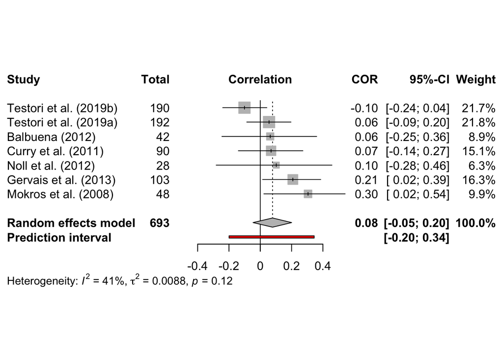

## Tests of Publication Bias

In this section, I examined the possibility of publication bias via the visual examination of funnel plots, Egger’s regression test, a simple meta-regression which regressed publication status (as a binary factor) on effect size, and PET-PEESE methods.

### Funnel Plot

The funnel plot does indicate some asymmetry, with few small studies finding negative results. Again, however, asymmetry in a funnel plot has several possible sources (Page et al., 2020):

- Publication bias and other reporting biases;
- Variability in methodological quality;
- Between-study heterogeneity;
- Artefactual variance (i.e., via the correlation between effect sizes and their standard error)
- Chance

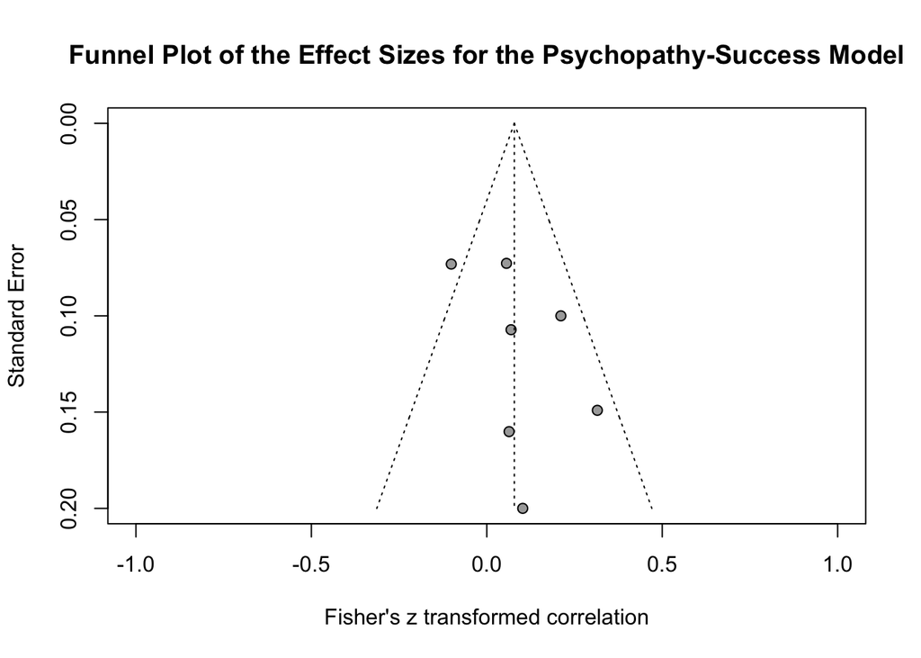

```r
meta::funnel(psyc.success,
             xlim = c(-1, 1),
             studlab = FALSE)

title("Funnel Plot of the Effect Sizes for the Psychopathy-Success Model")
```

### Egger’s Regression Test

Egger’s regression test (Egger et al., 1997) is a method that provides a statistical test of asymmetry in a funnel plot. It involves the prediction of standardized effect sizes on their precision.

The intercept (i.e., $\beta_0$) is of primary interest, representing the asymmetry of the plot. NHST can be used to test the null hypothesis that the intercept is equal to zero, indicating symmetry in the funnel plot. Conversely, a rejected null hypothesis for the intercept indicates asymmetry in the funnel plot - potentially due to publication bias.

The slope (i.e., $\beta_1$) represents the effect size adjusted for precision. It is expected to be consistent with the overall meta-analytic effect.

Reported below is the significance test and parameter estimate for the intercept.

```r
metabias(psyc.success,
         method.bias = "linreg",
         k.min = 5)
```

```
Review:     Psychopathy and Success in the PDG

Linear regression test of funnel plot asymmetry

Test result: t = 1.43, df = 5, p-value = 0.2118
Bias estimate: 1.9547 (SE = 1.3657)

Details:
- multiplicative residual heterogeneity variance (tau^2 = 1.4364)
- predictor: standard error
- weight:    inverse variance
- reference: Egger et al. (1997), BMJ
```

The intercept was not significant, indicating that there is not a substantial amount of asymmetry in the funnel plot.

### Publication Status as a Moderator of Effect Size

Simple meta-regression was used to predict effect sizes from publication status as a factor (i.e., 0 = unpublished, 1 = published). It should be noted that this is a provisional analysis, as meta-regression should not be used when there are fewer than 10 studies within a meta-analytic model (Deeks et al., 2023).

```r
mod.model.pub <- rma(yi = z_psyc_succ,
                           vi = var_z_psyc_succ,
                           data = PDG.remove.na,
                           method = "REML",
                           mods = ~ Publication_Status)

summary(mod.model.pub)
```

```
Mixed-Effects Model (k = 7; tau^2 estimator: REML)

  logLik  deviance       AIC       BIC      AICc
  2.3767   -4.7534    1.2466    0.0749   25.2466

tau^2 (estimated amount of residual heterogeneity):     0.0111 (SE = 0.0140)
tau (square root of estimated tau^2 value):             0.1054
I^2 (residual heterogeneity / unaccounted variability): 52.09%
H^2 (unaccounted variability / sampling variability):   2.09
R^2 (amount of heterogeneity accounted for):            0.00%

Test for Residual Heterogeneity:
QE(df = 5) = 10.1225, p-val = 0.0718

Test of Moderators (coefficient 2):
QM(df = 1) = 0.0092, p-val = 0.9236

Model Results:

                             estimate      se    zval    pval    ci.lb   ci.ub
intrcpt                        0.0635  0.1917  0.3312  0.7405  -0.3122  0.4392
Publication_StatusPublished    0.0193  0.2014  0.0959  0.9236  -0.3754  0.4140

intrcpt
Publication_StatusPublished

---
Signif. codes:  0 '***' 0.001 '**' 0.01 '*' 0.05 '.' 0.1 ' ' 1
```

The omnibus test indicates that there is no significant difference between published and unpublished studies, *QM*(1) = 0.009, *p* = .924.

### PET & PEESE Analyses

The PET (Precision-Effect Test) and PEESE (Precision-Effect Estimate with Standard Error) are two analytical methods designed to address publication bias in meta-analyses.

The former, PET analysis, is designed to determine the degree to which small-study effects and publication bias impact a meta-analysis. To do so, effect sizes are predicted from their standard errors. This analysis is used to provide evidence that a genuine effect exists beyond the effect of small-study effects/publication bias.

#### PET Analysis

The key element of the PET analysis is the estimate for $\beta_0$ or the intercept of the regression. According to the logic for PET analysis, a non-significant intercept indicates that no genuine effect occurs beyond small-study effects/publication bias. In contrast, a significant intercept provides evidence for a true effect.

That being said, one potential issue with both PET and PEESE analysis is the assumption that there is a homogenous distribution underlying effect sizes. Conceptually, this is similar to the assumption underlying fixed-effects meta-analyses (https://willgervais.com/blog/2015/6/25/putting-pet-peese-to-the-test-1). While this is problematic in and of itself, we will proceed using the PET-PEESE method.

```r
pet_model <- rma(yi = z_psyc_succ,
                     vi = var_z_psyc_succ,
                    mods = ~ z_se_psyc_succ,
                     data = PDG.remove.na,
                     method = "REML")

summary(pet_model)
```

```
Mixed-Effects Model (k = 7; tau^2 estimator: REML)

  logLik  deviance       AIC       BIC      AICc
  2.9631   -5.9262    0.0738   -1.0979   24.0738

tau^2 (estimated amount of residual heterogeneity):     0.0055 (SE = 0.0103)
tau (square root of estimated tau^2 value):             0.0739
I^2 (residual heterogeneity / unaccounted variability): 33.40%
H^2 (unaccounted variability / sampling variability):   1.50
R^2 (amount of heterogeneity accounted for):            38.17%

Test for Residual Heterogeneity:
QE(df = 5) = 7.1821, p-val = 0.2074

Test of Moderators (coefficient 2):
QM(df = 1) = 1.6162, p-val = 0.2036

Model Results:

                estimate      se     zval    pval    ci.lb   ci.ub
intrcpt          -0.1026  0.1471  -0.6977  0.4854  -0.3908  0.1856
z_se_psyc_succ    1.7022  1.3389   1.2713  0.2036  -0.9220  4.3264

---
Signif. codes:  0 '***' 0.001 '**' 0.01 '*' 0.05 '.' 0.1 ' ' 1
```

As seen in the output, the intercept in the model is not significant (*p* = .485). This indicates that no true effect exists beyond publication bias. While analysis would normally stop here, it must be noted, again, that this is a provisional analysis that goes against contemporary recommendations for the use of meta-regression when a model has fewer than 10 studies (Deeks et al., 2023). As the PET analysis is exploratory, we will continue to PEESE analysis.

#### PEESE Analysis

PEESE analysis aims to produce a precise estimate of the true effect size after accounting for sampling error, small-study effects, and publication bias. It does so by creating a regression where effect sizes are predicted by the squared standard errors of studies.

Again, the primary parameter estimate of interest is $\beta_0$, which indicates the estimate of the true effect size (after adjusting for sampling error, small-study effects, and publication bias). Significance tests are interpreted such that a significant intercept indicates a significant meta-analytic effect size.

A secondary parameter estimate of interest is $\beta_1$, which indicates the relationship between effect sizes and their variances. When this is significant, there is evidence that effect sizes are systematically related to the estimate of their precision (i.e., their variance), which may suggest the presence of small-study effects or publication bias.

More particularly, a positive slope indicates that larger variances (with larger standard errors, and, oftentimes, smaller sample sizes) report larger effect sizes. This is representative of the typical “small-study effect” and indicates potential publication bias.

In contrast, a negative slope suggests that smaller studies report smaller effect sizes and larger studies report larger effect sizes. This may indicate other sources of bias or sources of heterogeneity impacting the results.

```r
peese_model <- rma(yi = z_psyc_succ,
                     vi = var_z_psyc_succ,
                    mods = ~ var_z_psyc_succ,
                     data = PDG.remove.na,
                     method = "REML")

summary(peese_model)
```

```
Mixed-Effects Model (k = 7; tau^2 estimator: REML)

  logLik  deviance       AIC       BIC      AICc
  2.8022   -5.6044    0.3956   -0.7761   24.3956

tau^2 (estimated amount of residual heterogeneity):     0.0068 (SE = 0.0112)
tau (square root of estimated tau^2 value):             0.0826
I^2 (residual heterogeneity / unaccounted variability): 39.09%
H^2 (unaccounted variability / sampling variability):   1.64
R^2 (amount of heterogeneity accounted for):            22.76%

Test for Residual Heterogeneity:
QE(df = 5) = 7.9468, p-val = 0.1592

Test of Moderators (coefficient 2):
QM(df = 1) = 1.0371, p-val = 0.3085

Model Results:

                 estimate      se    zval    pval    ci.lb    ci.ub
intrcpt            0.0071  0.0852  0.0828  0.9340  -0.1600   0.1741
var_z_psyc_succ    5.5531  5.4528  1.0184  0.3085  -5.1343  16.2405

---
Signif. codes:  0 '***' 0.001 '**' 0.01 '*' 0.05 '.' 0.1 ' ' 1
```

```r
convert_z2r(.0071)
```

```
[1] 0.007099881
```

As seen in the model output, the PEESE method indicates that the true effect size is *r* = .007 and non-significant at *p* = .934. This differs substantially from the model estimate of *r* = .078. Again, meta-regression should not be used in general when *k* < 10 and the PET-PEESE method has been acknowledged to (a) perform poorly under conditions of small sample size (i.e., *k* < 20) and high between-study heterogeneity (i.e., *I*<sup>2</sup> > 80) and (b) heavily over-corrects for bias in the data (Carter et al., 2019).

The slope coefficient indicates a non-significant, positive relationship between effect sizes and their variances (see above). Interestingly, the non-significance of the slope indicates that publication bias is not large enough to have affected the results.

To illustrate the slope estimated by the model visually, we will plot the regression.

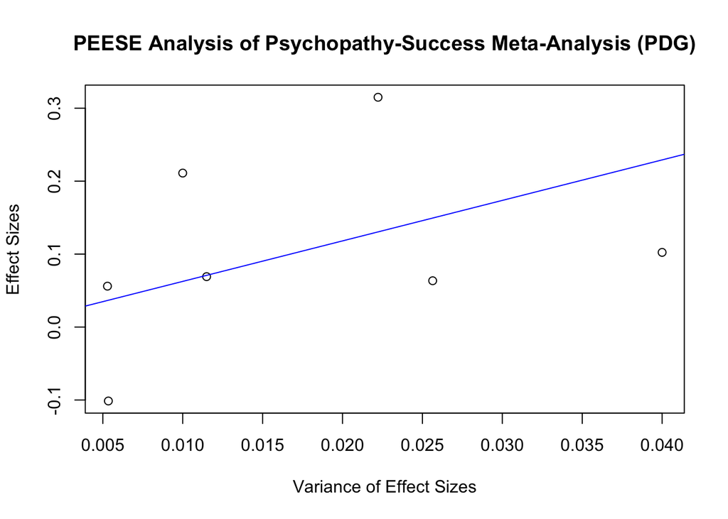

```r
plot(
  PDG.remove.na$var_z_psyc_succ, PDG.remove.na$z_psyc_succ,
  xlab = "Variance of Effect Sizes",
  ylab = "Effect Sizes",
  main = "PEESE Analysis of Psychopathy-Success Meta-Analysis (PDG)"
)
abline(a = coef(peese_model)[1], b = coef(peese_model)[2], col = "blue")
```

### Fail-Safe *N*

A variation of Orwin’s (1983) fail-safe N test was used to indicate the number of studies with null effects needed to reduce the effect size to a practically irrelevant size (Viechtbauer, 2010). Practical insignificance was demarked by an effect size of r = |.05|, depending on the direction of the summary effect.

```r
fail.safe <- rma(yi = z_psyc_succ,
                 vi = var_z_psyc_succ,
                 slab = Study,
                 data = PDG.remove.na,
                 method = "REML")

fsn(fail.safe, type = "General", target = 0.05)
```

```
Fail-safe N Calculation Using the General Approach

Average Effect Size:         0.0784 (with file drawer: 0.0483)
Amount of Heterogeneity:     0.0088 (with file drawer: 0.0095)
Observed Significance Level: 0.1572 (with file drawer: 0.2729)
Target Effect Size:          0.0500

Fail-safe N: 5
```

## Sensitivity Analysis Omitting Testori (2019b)

As an exploratory step, a sensitivity analysis was conducted by running a random-effects meta-analytic model after omitting the results of Testori (2019b). As can be seen in the funnel plot, this is the only (a) negative effect size and (b) effect size outside of the demarked bounds of the funnel plot.

```r
omit.testori2019b <- PDG.remove.na[-c(7), ]

psyc.success.omit <- metacor(cor = Psychopathy_Succ,
                        n = n_effect,
                        studlab = Study,
                        data = omit.testori2019b,
                        fixed = FALSE,
                        random = TRUE,
                        method.tau = "REML",
                        method.random.ci = "HK",
                        title = "Psychopathy and Success in the PDG")

summary(psyc.success.omit)
```

```
Review:     Psychopathy and Success in the PDG

                          COR            95%-CI %W(random)
Balbuena (2012)        0.0634 [-0.2453; 0.3604]        8.0
Curry et al. (2011)    0.0690 [-0.1401; 0.2722]       17.9
Gervais et al. (2013)  0.2080 [ 0.0151; 0.3860]       20.6
Mokros et al. (2008)   0.3050 [ 0.0228; 0.5422]        9.3
Noll et al. (2012)     0.1020 [-0.2818; 0.4577]        5.2
Testori et al. (2019a) 0.0560 [-0.0863; 0.1961]       39.0

Number of studies: k = 6
Number of observations: o = 503

                        COR           95%-CI    t p-value
Random effects model 0.1168 [0.0174; 0.2140] 3.02  0.0295

Quantifying heterogeneity:
 tau^2 = 0 [0.0000; 0.0481]; tau = 0 [0.0000; 0.2193]
 I^2 = 0.0% [0.0%; 74.6%]; H = 1.00 [1.00; 1.99]

Test of heterogeneity:
    Q d.f. p-value
 3.67    5  0.5981

Details on meta-analytical method:
- Inverse variance method
- Restricted maximum-likelihood estimator for tau^2
- Q-Profile method for confidence interval of tau^2 and tau
- Hartung-Knapp adjustment for random effects model (df = 5)
- Fisher's z transformation of correlations
```

The results of this analysis suggest that psychopathy is significantly associated with success in the PDG, *r* = .117, 95% CI [.017, .214], *p* = .030. Interestingly, between-study heterogeneity functionally “disappears”, with a non-significant Cochran’s *Q* test, *Q*(5) = 3.67, *p* = .598, and a $\tau$<sup>2</sup> of 0.

## Exploratory Analysis: One-shot vs. Iterated

Although meta-regression should not be used when there are fewer than 10 studies in a meta-analytic model (Deeks et al., 2023), I will be conducting an exploratory analysis to examine the parameter estimates of the psychopathy-success relationship in one-shot vs. iterated games.

```r
psyc.success <- metacor(cor = Psychopathy_Succ,
                 n = n_effect,
                 studlab = Study,
                 data = PDG.remove.na,
                 fixed = FALSE,
                 random = TRUE,
                 method.tau = "REML",
                 method.random.ci = "HK",
                 title = "Psychopathy and Success in the PDG",
                 subgroup = Iterated)

summary(psyc.success)
```

```
Review:     Psychopathy and Success in the PDG

                           COR            95%-CI %W(random) Iterated
Balbuena (2012)         0.0634 [-0.2453; 0.3604]        8.9 Iterated
Curry et al. (2011)     0.0690 [-0.1401; 0.2722]       15.1 One-shot
Gervais et al. (2013)   0.2080 [ 0.0151; 0.3860]       16.3 One-shot
Mokros et al. (2008)    0.3050 [ 0.0228; 0.5422]        9.9 Iterated
Noll et al. (2012)      0.1020 [-0.2818; 0.4577]        6.3 Iterated
Testori et al. (2019a)  0.0560 [-0.0863; 0.1961]       21.8 Iterated
Testori et al. (2019b) -0.1010 [-0.2399; 0.0420]       21.7 Iterated

Number of studies: k = 7
Number of observations: o = 693

                        COR            95%-CI    t p-value
Random effects model 0.0783 [-0.0463; 0.2004] 1.54  0.1749

Quantifying heterogeneity:
 tau^2 = 0.0088 [0.0000; 0.0705]; tau = 0.0940 [0.0000; 0.2654]
 I^2 = 40.7% [0.0%; 75.1%]; H = 1.30 [1.00; 2.00]

Test of heterogeneity:
     Q d.f. p-value
 10.12    6  0.1195

Results for subgroups (random effects model):
                      k    COR            95%-CI  tau^2    tau    Q   I^2
Iterated = One-shot   2 0.1440 [-0.6380; 0.7798]      0      0 0.94  0.0%
Iterated = Iterated   5 0.0525 [-0.1325; 0.2339] 0.0110 0.1051 7.16 44.1%

Test for subgroup differences (random effects model):
                  Q d.f. p-value
Between groups 0.90    1  0.3423

Details on meta-analytical method:
- Inverse variance method
- Restricted maximum-likelihood estimator for tau^2
- Q-Profile method for confidence interval of tau^2 and tau
- Hartung-Knapp adjustment for random effects model (df = 6)
- Fisher's z transformation of correlations
```

While there is little power to detect differences (and limited studies in the one-shot condition), it is interesting that the meta-analytic estimate of the correlation between psychopathy-success is higher in one-shot studies (*r* = .1440) than in iterated studies (*r* = .0525).